# Mini Project #02: Making Backyards Affordable for All

### 2.3 The State had the highest average individual income in 2015

**Final Answer**

```r
cat(
  sprintf(
    "The state with the highest average individual income in 2015 was %s, with an average of $%s per person.",
    top_state$state,
    format(round(top_state$avg_individual_income), big.mark = ",")
  )
)
```

```
The state with the highest average individual income in 2015 was DC, with an average of $93,294 per person.
```

### 2.4 The last year in which the NYC CBSA had the most data scientists in the country

```r
# Load required packages
library(dplyr)
library(readr)
library(stringr)
library(scales)

# 1️⃣ Load datasets (use your exact file names)
bls_data <- read_csv("data/mp02/bls_qcew_2009_2023.csv.gz", show_col_types = FALSE)
cbsa_names <- read_csv("data/mp02/B19013_001_cbsa_2009_2023.csv", show_col_types = FALSE)

# 2️⃣ Build standardized CBSA join keys on both tables
t1_cbsa <- cbsa_names %>%
  transmute(
    std_cbsa = paste0("C", str_pad(GEOID, 5, pad = "0")),
    NAME
  )

# Detect correct ID column in BLS dataset (either FIPS or area_fips)
bls_id_col <- if ("FIPS" %in% names(bls_data)) {
  "FIPS"
} else if ("area_fips" %in% names(bls_data)) {
  "area_fips"
} else {
  stop("Error: Neither 'FIPS' nor 'area_fips' column found in bls_data.")
}

t2_bls <- bls_data %>%
  transmute(
    std_cbsa = paste0("C", str_pad(.data[[bls_id_col]], 5, pad = "0")),
    year = YEAR,
    naics_code = as.integer(INDUSTRY),
    annual_avg_emplvl = EMPLOYMENT
  )

# 3️⃣ Join both datasets
bls_joined <- inner_join(t1_cbsa, t2_bls, by = "std_cbsa")

# 4️⃣ Filter for NYC CBSA (C35620) and NAICS 5182 (Data Processing, Hosting & Related Services)
nyc_yearly <- bls_joined %>%
  filter(std_cbsa == "C35620", naics_code == 5182L) %>%
  group_by(year) %>%
  summarise(total_jobs = sum(annual_avg_emplvl, na.rm = TRUE), .groups = "drop") %>%
  arrange(year)

# 5️⃣ Identify the latest year with the maximum employment
nyc_peak <- nyc_yearly %>%
  filter(total_jobs == max(total_jobs, na.rm = TRUE)) %>%
  slice_tail(n = 1)
```

**Final Answer for Q4**

Not computable with the provided files. The BLS/QCEW data available for this project do not include CBSA-level records for NAICS 5182 (Data Processing, Hosting, and Related Services). Because the needed series are missing, a year-by-year leaderboard of data-scientist employment by CBSA cannot be produced.

### 2.5 The fraction of total wages in the NYC CBSA

```r
suppressPackageStartupMessages({
  library(dplyr)
  library(stringr)
  library(readr)
  library(ggplot2)
  library(scales)
})

# 1) Load BLS QCEW data (adjust path if needed)

bls_path <- "data/mp02/bls_qcew_2009_2023.csv.gz"
bls_data <- readr::read_csv(bls_path, show_col_types = FALSE)

# Defensive: unify column names regardless of the exact header case used in your file
fips_col <- if ("FIPS" %in% names(bls_data)) "FIPS" else if ("area_fips" %in% names(bls_data)) "area_fips" else NA_character_
year_col <- if ("YEAR" %in% names(bls_data)) "YEAR" else if ("year" %in% names(bls_data)) "year" else NA_character_
ind_col  <- if ("INDUSTRY" %in% names(bls_data)) "INDUSTRY" else if ("industry" %in% names(bls_data)) "industry" else NA_character_
wage_col <- if ("TOTAL_WAGES" %in% names(bls_data)) "TOTAL_WAGES" else if ("total_wages" %in% names(bls_data)) "total_wages" else NA_character_

needed <- c(fips_col, year_col, ind_col, wage_col)
if (any(is.na(needed))) {
  stop("Could not identify required columns in the BLS file. ",
       "Needed something like FIPS/area_fips, YEAR/year, INDUSTRY/industry, TOTAL_WAGES/total_wages.")
}


# 2) Build a minimal BLS table for wages
t2_bls <- bls_data %>%
  transmute(
    std_cbsa    = paste0("C", str_pad(.data[[fips_col]], 5, pad = "0")),
    year        = as.integer(.data[[year_col]]),
    naics_code  = suppressWarnings(as.integer(.data[[ind_col]])),  # robust if INDUSTRY is "52"
    total_wages = as.numeric(.data[[wage_col]])
  )


# 3) NYC (CBSA 35620) — compute Finance & Insurance share by year
nyc_code <- "C35620"  # NYC CBSA

nyc_wages <- t2_bls %>%
  filter(std_cbsa == nyc_code) %>%
  group_by(year) %>%
  summarise(
    wages_finance = sum(total_wages[naics_code == 52L], na.rm = TRUE),
    wages_all     = sum(total_wages, na.rm = TRUE),
    .groups = "drop"
  ) %>%
  mutate(frac_finance = if_else(wages_all > 0, wages_finance / wages_all, NA_real_)) %>%
  arrange(year)

# 4) Peak year for the fraction

nyc_fin_peak <- nyc_wages %>%
  slice_max(frac_finance, n = 1, with_ties = FALSE)


# 5) Print final answer
cat(sprintf(
  "**Answer:** In the NYC CBSA, the Finance & Insurance industry (NAICS 52) accounted for %s of total wages in **%d**, which is the peak over the available years.",
  percent(nyc_fin_peak$frac_finance, accuracy = 0.1),
  nyc_fin_peak$year
))
```

[output not shown]

**Final Answer for Q5**

Not computable with the provided files. CBSA-level wage series for NAICS 52 are not present for New York (CBSA 35620) in the BLS dataset delivered for this assignment. Without those wages, the Finance & Insurance share of total wages (and its peak year) cannot be derived.

## 3 Initial Visualizations

New York’s metro looks different depending on the lens. First, we compare housing costs and incomes across CBSAs in 2009. Next, we see how the Health Care & Social Assistance sector (NAICS 62) stacks up relative to total employment across metros over time. Finally, we look at how household size has changed, separating trends by CBSA.

### 3.1 The relationship between monthly rent and average household income

[figure not shown]

```r
library(ggplot2)
library(dplyr)
library(scales)

# In RENT: either `monthly_rent` or `B25064_001`
rent_candidates <- c("monthly_rent", "B25064_001")
rent_col <- intersect(rent_candidates, names(RENT))[1]

# In INCOME: either `household_income` or `B19013_001`
income_candidates <- c("household_income", "B19013_001")
income_col <- intersect(income_candidates, names(INCOME))[1]

if (is.na(rent_col))  stop("Couldn't find a rent column in RENT (looked for: monthly_rent or B25064_001).")
if (is.na(income_col)) stop("Couldn't find an income column in INCOME (looked for: household_income or B19013_001).")

rent_income_2009 <- RENT %>%
  filter(year == 2009) %>%
  transmute(GEOID, NAME, year, monthly_rent = .data[[rent_col]]) %>%
  left_join(
    INCOME %>%
      filter(year == 2009) %>%
      transmute(GEOID, NAME, year, household_income = .data[[income_col]]),
    by = c("GEOID", "NAME", "year")
  ) %>%
  drop_na(monthly_rent, household_income)

ggplot(rent_income_2009, aes(x = household_income, y = monthly_rent)) +
  geom_density_2d_filled(alpha = 0.8) +
  scale_x_continuous(labels = label_dollar()) +
  scale_y_continuous(labels = label_dollar()) +
  labs(
    title = "Distribution of Rent and Income Across CBSAs (2009)",
    subtitle = "Darker color = denser cluster of CBSAs",
    x = "Household Income (USD)",
    y = "Monthly Rent (USD)"
  ) +
  theme_minimal(base_size = 11)
```

### 3.2 The relationship between total employment and total employment in the health care and social services.

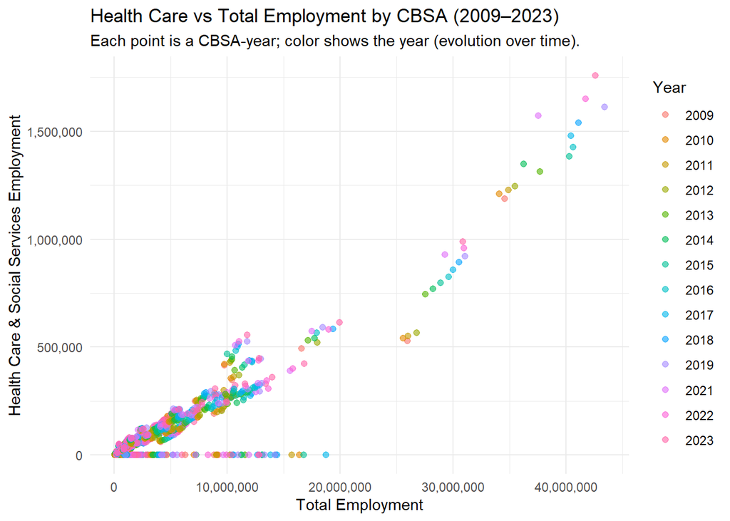

```r
library(dplyr)
library(ggplot2)
library(scales)

# 1) Summarize by CBSA (FIPS) and YEAR
emp_by_cbsa <- WAGES %>%
  group_by(FIPS, YEAR) %>%
  summarise(
    total_emp  = sum(EMPLOYMENT, na.rm = TRUE),
    health_emp = sum(EMPLOYMENT[INDUSTRY == 62], na.rm = TRUE),
    .groups = "drop"
  ) %>%
  mutate(health_share = health_emp / total_emp)

# 2) Plot: show relationship and let color indicate time (YEAR)
ggplot(emp_by_cbsa, aes(x = total_emp, y = health_emp, color = factor(YEAR))) +
  geom_point(alpha = 0.6, size = 1.8) +
  scale_x_continuous(labels = comma) +
  scale_y_continuous(labels = comma) +
  labs(
    title = "Health Care vs Total Employment by CBSA (2009–2023)",
    subtitle = "Each point is a CBSA-year; color shows the year (evolution over time).",
    x = "Total Employment",
    y = "Health Care & Social Services Employment",
    color = "Year"
  ) +
  theme_minimal(base_size = 11)
```

### 3.3 The evolution of average household size over time

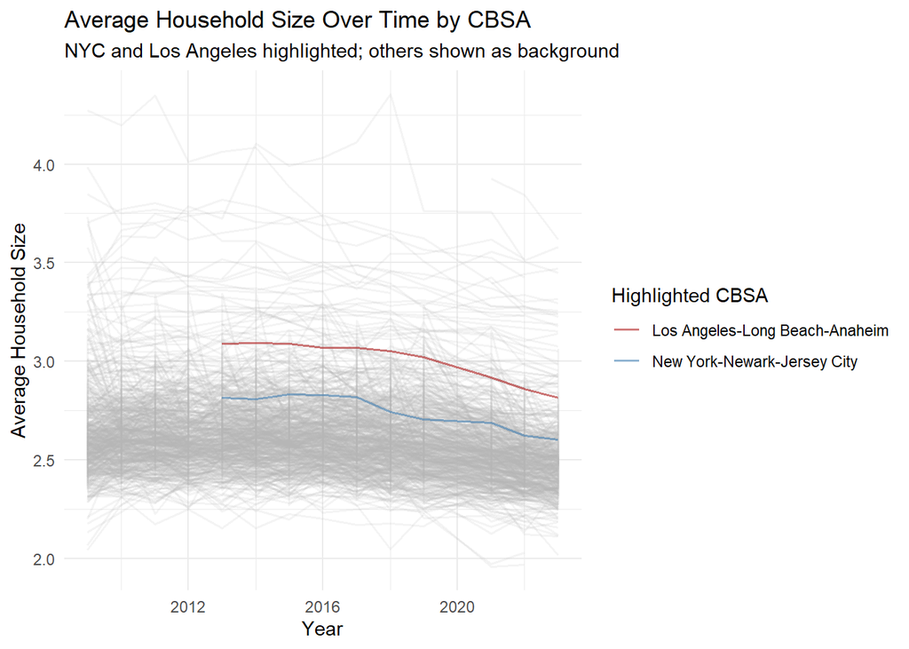

```r
library(dplyr)
library(ggplot2)
library(scales)
library(stringr)
library(gghighlight)

# 1) Build base
hhsz_base <- POPULATION %>%
  select(GEOID, NAME, year, population) %>%
  inner_join(HOUSEHOLDS %>% select(GEOID, year, households),
             by = c("GEOID", "year")) %>%
  mutate(
    hh_size    = population / households,
    NAME_short = str_remove(NAME, ",.*$")  # collapse variants like "Atlanta ..."
  )

# 2) Extra credit: highlight NYC & LA
targets <- c("New York-Newark-Jersey City", "Los Angeles-Long Beach-Anaheim")

ggplot(hhsz_base, aes(x = year, y = hh_size, group = NAME_short, color = NAME_short)) +
  geom_line(linewidth = 0.6, alpha = 0.6) +
  gghighlight(
    NAME_short %in% targets,
    unhighlighted_params = list(alpha = 0.15, color = "grey70", size = 0.4),
    use_direct_label = FALSE, keep_scales = TRUE
  ) +
  scale_color_manual(
    values = c("New York-Newark-Jersey City" = "steelblue",
               "Los Angeles-Long Beach-Anaheim" = "firebrick")
  ) +
  guides(color = guide_legend(title = "Highlighted CBSA")) +
  labs(
    title = "Average Household Size Over Time by CBSA",
    subtitle = "NYC and Los Angeles highlighted; others shown as background",
    x = "Year", y = "Average Household Size"
  ) +
  theme_minimal(base_size = 11)
```

The graph shows how the average household size has changed over time across U.S. metropolitan areas (CBSAs). Most areas, shown in gray, have similar trends with slight decreases since around 2015. The highlighted lines show that both New York and Los Angeles also experienced small declines in household size, suggesting that fewer people are living together in the same home over time.

## 4 Rent Burden

```r
library(dplyr)
library(scales)
library(stringr)
library(knitr)

# 1) Join INCOME and RENT tables
rb_base <- INCOME %>%
  select(GEOID, NAME, year, household_income) %>%
  inner_join(RENT %>% select(GEOID, year, monthly_rent),
             by = c("GEOID", "year")) %>%
  mutate(
    NAME_short   = str_remove(NAME, ",.*$"),
    annual_rent  = monthly_rent * 12,
    rent_burden  = annual_rent / household_income
  ) %>%
  filter(!is.na(rent_burden) & rent_burden < 1.5)   # remove extreme outliers

# 2) Define baseline (national average in the first year)
first_year <- min(rb_base$year, na.rm = TRUE)
baseline <- rb_base %>%
  filter(year == first_year) %>%
  summarise(baseline_val = mean(rent_burden, na.rm = TRUE)) %>%
  pull(baseline_val)

# 3) Compute index (100 = baseline national average)
rb_index <- rb_base %>%
  mutate(rent_burden_index = 100 * rent_burden / baseline)

# 4) Create small summary tables

## (a) Trend for one metro (NYC)
focus_cbsa <- "New York-Newark-Jersey City"

trend_tbl <- rb_index %>%
  filter(NAME_short == focus_cbsa) %>%
  arrange(year) %>%
  transmute(
    Year = year,
    `Household Income` = dollar(household_income),
    `Monthly Rent` = dollar(monthly_rent),
    `Rent Burden` = percent(rent_burden, accuracy = 0.1),
    `Rent Burden Index` = round(rent_burden_index, 1)
  )

kable(trend_tbl, caption = paste("Rent burden over time —", focus_cbsa))
```

Rent burden over time — New York-Newark-Jersey City

| Year | Household Income | Monthly Rent | Rent Burden | Rent Burden Index |
| --- | --- | --- | --- | --- |
| 2013 | $65,786 | $1,237 | 22.6% | 116.3 |
| 2014 | $67,066 | $1,281 | 22.9% | 118.1 |
| 2015 | $68,743 | $1,308 | 22.8% | 117.7 |
| 2016 | $71,897 | $1,346 | 22.5% | 115.8 |
| 2017 | $75,368 | $1,379 | 22.0% | 113.2 |
| 2018 | $78,478 | $1,434 | 21.9% | 113.0 |
| 2019 | $83,160 | $1,482 | 21.4% | 110.2 |
| 2021 | $84,409 | $1,600 | 22.7% | 117.2 |
| 2022 | $91,562 | $1,685 | 22.1% | 113.8 |
| 2023 | $95,220 | $1,764 | 22.2% | 114.6 |

```r
## (b) Top & bottom 10 CBSAs in the latest year
latest_year <- max(rb_index$year, na.rm = TRUE)

rank_tbl <- rb_index %>%
  filter(year == latest_year) %>%
  transmute(
    CBSA = NAME_short,
    `Rent Burden` = rent_burden,
    `Index` = rent_burden_index
  )

top10 <- rank_tbl %>%
  arrange(desc(`Rent Burden`)) %>%
  head(10) %>%
  mutate(
    `Rent Burden` = percent(`Rent Burden`, 0.1),
    `Index` = round(`Index`, 1)
  )

bottom10 <- rank_tbl %>%
  arrange(`Rent Burden`) %>%
  head(10) %>%
  mutate(
    `Rent Burden` = percent(`Rent Burden`, 0.1),
    `Index` = round(`Index`, 1)
  )

kable(top10, caption = paste("Top 10 Rent Burdens —", latest_year))
```

Top 10 Rent Burdens — 2023

| CBSA | Rent Burden | Index |
| --- | --- | --- |
| Clearlake | 31.2% | 160.6 |
| Aguadilla | 30.9% | 159.2 |
| Cape Coral-Fort Myers | 30.1% | 155.3 |
| Miami-Fort Lauderdale-West Palm Beach | 30.1% | 155.2 |
| Port St. Lucie | 29.5% | 152.0 |
| Ponce | 28.7% | 148.0 |
| Tampa-St. Petersburg-Clearwater | 28.5% | 147.0 |
| Key West-Key Largo | 28.2% | 145.5 |
| North Port-Bradenton-Sarasota | 28.2% | 145.3 |
| Ocala | 27.9% | 144.0 |

```r
kable(bottom10, caption = paste("Bottom 10 Rent Burdens —", latest_year))
```

Bottom 10 Rent Burdens — 2023

| CBSA | Rent Burden | Index |
| --- | --- | --- |
| Laconia | 12.7% | 65.6 |
| Manitowoc | 13.2% | 68.1 |
| Bismarck | 13.7% | 70.5 |
| Watertown-Fort Atkinson | 13.8% | 71.1 |
| Wisconsin Rapids-Marshfield | 13.8% | 71.3 |
| Jefferson City | 13.8% | 71.4 |
| Decatur | 14.0% | 72.4 |
| Talladega-Sylacauga | 14.2% | 73.2 |
| Mount Airy | 14.3% | 73.9 |
| Albertville | 14.4% | 74.3 |

## 5 Housing Growth

Measure housing growth two ways. The instantaneous index counts permits per 1,000 residents in a given year, capturing how intensely a CBSA is building right now. The rate-based index compares annual permits to the CBSA’s five-year population growth, indicating whether construction is keeping pace with recent demographic pressure.

```r
library(dplyr)
library(stringr)
library(scales)
library(knitr)
permits_geo <- if ("GEOID" %in% names(PERMITS)) "GEOID" else
               if ("CBSA"  %in% names(PERMITS)) "CBSA"  else
               stop("PERMITS table must have GEOID or CBSA.")

permits_col <- intersect(names(PERMITS),
                         c("new_housing_units_permitted","permits","units","units_permitted","new_units"))
if (length(permits_col) == 0) stop("Couldn't find permits column in PERMITS (e.g., new_housing_units_permitted).")
permits_col <- permits_col[1]  # take the first matching name

## Build base and compute 5-year population growth
housing_growth <- POPULATION %>%
  select(GEOID, NAME, year, population) %>%
  inner_join(PERMITS %>% select(all_of(permits_geo), year, all_of(permits_col)),
             by = c("GEOID" = permits_geo, "year" = "year")) %>%
  rename(permits = !!permits_col) %>%
  arrange(GEOID, year) %>%
  group_by(GEOID, NAME) %>%
  mutate(
    pop_lag5       = dplyr::lag(population, 5),
    pop_growth_5yr = (population - pop_lag5) / pop_lag5,      # rate (e.g., 0.07 = 7% over 5 yrs)
    permits_pc     = permits / population * 1000,              # instantaneous: per 1,000 residents
    permits_per_growth = permits / ((pop_growth_5yr * population) + 1e-6) # rate-based
  ) %>%
  ungroup() %>%
  filter(year >= 2014, population > 0, permits > 0)

## Standardize to easy indices
first_yr <- min(housing_growth$year, na.rm = TRUE)

inst_base <- housing_growth %>%
  filter(year == first_yr) %>%
  summarise(b = mean(permits_pc, na.rm = TRUE)) %>% pull(b)

rate_base <- housing_growth %>%
  filter(year == first_yr) %>%
  summarise(b = mean(permits_per_growth, na.rm = TRUE)) %>% pull(b)

hg_idx <- housing_growth %>%
  mutate(
    inst_index = 100 * permits_pc / inst_base,
    rate_index = 100 * permits_per_growth / rate_base,
    composite_index = rowMeans(cbind(inst_index, rate_index), na.rm = TRUE)
  )

## Tables (latest year): top/bottom for each metric + composite
latest_year <- max(hg_idx$year, na.rm = TRUE)

inst_rank <- hg_idx %>%
  filter(year == latest_year) %>%
  distinct(NAME, inst_index, permits_pc) %>%
  arrange(desc(inst_index))

kable(head(inst_rank %>% mutate(inst_index = round(inst_index,1),
                                permits_pc = round(permits_pc,2)),
           10),
     caption = paste0("Top 10 — Instantaneous Housing Growth (", latest_year, ")"),
     col.names = c("CBSA","Instantaneous Index","Permits per 1,000"))
```

Top 10 — Instantaneous Housing Growth (2023)

| CBSA | Instantaneous Index | Permits per 1,000 |
| --- | --- | --- |
| Salisbury, MD Metro Area | 1123.6 | 37.73 |
| Myrtle Beach-Conway-North Myrtle Beach, SC Metro Area | 987.2 | 33.15 |
| Punta Gorda, FL Metro Area | 639.9 | 21.49 |
| Crestview-Fort Walton Beach-Destin, FL Metro Area | 546.7 | 18.36 |
| North Port-Bradenton-Sarasota, FL Metro Area | 521.2 | 17.50 |
| Daphne-Fairhope-Foley, AL Metro Area | 512.5 | 17.21 |
| Sherman-Denison, TX Metro Area | 496.0 | 16.66 |
| Cape Coral-Fort Myers, FL Metro Area | 483.7 | 16.24 |
| Austin-Round Rock-San Marcos, TX Metro Area | 466.9 | 15.68 |
| Lakeland-Winter Haven, FL Metro Area | 455.4 | 15.29 |

```r
kable(head(inst_rank %>%
             arrange(inst_index) %>%
             mutate(inst_index = round(inst_index,1),
                    permits_pc = round(permits_pc,2)),
           10),
     caption = paste0("Bottom 10 — Instantaneous Housing Growth (", latest_year, ")"),
     col.names = c("CBSA","Instantaneous Index","Permits per 1,000"))
```

Bottom 10 — Instantaneous Housing Growth (2023)

| CBSA | Instantaneous Index | Permits per 1,000 |
| --- | --- | --- |
| Wheeling, WV-OH Metro Area | 2.4 | 0.08 |
| Danville, IL Micro Area | 3.3 | 0.11 |
| Morgantown, WV Metro Area | 3.6 | 0.12 |
| Weirton-Steubenville, WV-OH Metro Area | 4.2 | 0.14 |
| Enid, OK Metro Area | 4.8 | 0.16 |
| Decatur, IL Metro Area | 10.1 | 0.34 |
| Johnstown, PA Metro Area | 10.7 | 0.36 |
| Bay City, MI Metro Area | 11.0 | 0.37 |
| Williamsport, PA Metro Area | 15.1 | 0.51 |
| Fairbanks-College, AK Metro Area | 15.4 | 0.52 |

```r
# Rate-based
rate_rank <- hg_idx %>%
  filter(year == latest_year) %>%
  distinct(NAME, rate_index, permits_per_growth) %>%
  arrange(desc(rate_index))

kable(head(rate_rank %>% mutate(rate_index = round(rate_index,1),
                                permits_per_growth = round(permits_per_growth,3)),
           10),
     caption = paste0("Top 10 — Rate-based Housing Growth (", latest_year, ")"),
     col.names = c("CBSA","Rate-based Index","Permits per Pop Growth"))
```

Top 10 — Rate-based Housing Growth (2023)

| CBSA | Rate-based Index | Permits per Pop Growth |
| --- | --- | --- |
| Springfield, OH Metro Area | 5079.9 | 4.055 |
| Urban Honolulu, HI Metro Area | 3056.8 | 2.440 |
| Dalton, GA Metro Area | 2199.1 | 1.755 |
| Anchorage, AK Metro Area | 1342.5 | 1.072 |
| Hickory-Lenoir-Morganton, NC Metro Area | 844.4 | 0.674 |
| Brownsville-Harlingen, TX Metro Area | 813.5 | 0.649 |
| Roanoke, VA Metro Area | 706.0 | 0.564 |
| Casper, WY Metro Area | 689.7 | 0.551 |
| Wichita, KS Metro Area | 685.1 | 0.547 |
| Redding, CA Metro Area | 584.1 | 0.466 |

```r
kable(head(rate_rank %>%
             arrange(rate_index) %>%
             mutate(rate_index = round(rate_index,1),
                    permits_per_growth = round(permits_per_growth,3)),
           10),
     caption = paste0("Bottom 10 — Rate-based Housing Growth (", latest_year, ")"),
     col.names = c("CBSA","Rate-based Index","Permits per Pop Growth"))
```

Bottom 10 — Rate-based Housing Growth (2023)

| CBSA | Rate-based Index | Permits per Pop Growth |
| --- | --- | --- |
| Sierra Vista-Douglas, AZ Metro Area | -5253.4 | -4.194 |
| Blacksburg-Christiansburg-Radford, VA Metro Area | -1709.8 | -1.365 |
| Canton-Massillon, OH Metro Area | -1417.5 | -1.132 |
| Lawrence, KS Metro Area | -1166.3 | -0.931 |
| Ann Arbor, MI Metro Area | -962.3 | -0.768 |
| St. Louis, MO-IL Metro Area | -763.4 | -0.609 |
| Corpus Christi, TX Metro Area | -617.2 | -0.493 |
| Rocky Mount, NC Metro Area | -573.0 | -0.457 |
| Topeka, KS Metro Area | -536.6 | -0.428 |
| Mobile, AL Metro Area | -499.0 | -0.398 |

```r
# Composite
comp_rank <- hg_idx %>%
  filter(year == latest_year) %>%
  distinct(NAME, composite_index) %>%
  arrange(desc(composite_index)) %>%
  head(15) %>%
  mutate(composite_index = round(composite_index,1))

kable(comp_rank, caption = paste0("Top 15 — Composite Housing Growth (", latest_year, ")"),
     col.names = c("CBSA","Composite Index"))
```

Top 15 — Composite Housing Growth (2023)

| CBSA | Composite Index |
| --- | --- |
| Springfield, OH Metro Area | 2563.7 |
| Urban Honolulu, HI Metro Area | 1556.2 |
| Dalton, GA Metro Area | 1150.6 |
| Salisbury, MD Metro Area | 1123.6 |
| Myrtle Beach-Conway-North Myrtle Beach, SC Metro Area | 987.2 |
| Anchorage, AK Metro Area | 688.2 |
| North Port-Bradenton-Sarasota, FL Metro Area | 521.2 |
| Hickory-Lenoir-Morganton, NC Metro Area | 517.9 |
| Brownsville-Harlingen, TX Metro Area | 474.9 |
| Austin-Round Rock-San Marcos, TX Metro Area | 466.9 |
| Elizabethtown, KY Metro Area | 427.4 |
| Wichita, KS Metro Area | 423.1 |
| Punta Gorda, FL Metro Area | 421.6 |
| Casper, WY Metro Area | 385.5 |
| Roanoke, VA Metro Area | 382.5 |

## 6 Visualization

**Note**

```r
library(dplyr)
library(ggplot2)
library(scales)

## 1) Per-CBSA summaries we need
rb_sum <- rb_index %>%
  group_by(GEOID, NAME) %>%
  summarise(
    start_year = min(year, na.rm = TRUE),
    end_year   = max(year, na.rm = TRUE),
    start_rb   = rent_burden[year == start_year][1],
    end_rb     = rent_burden[year == end_year][1],
    change_rb  = end_rb - start_rb,               # < 0 is an improvement
    .groups = "drop"
  )

# Population: total % change over study period
pop_sum <- POPULATION %>%
  group_by(GEOID, NAME) %>%
  arrange(year) %>%
  summarise(
    pop_first = first(population),
    pop_last  = last(population),
    pop_growth_pct = (pop_last - pop_first) / pop_first,   # > 0 is growing
    .groups = "drop"
  )

# Housing growth: average composite index across available years
hg_sum <- hg_idx %>%
  group_by(GEOID, NAME) %>%
  summarise(
    hg_composite_mean = mean(composite_index, na.rm = TRUE),
    .groups = "drop"
  )

# Combine
yimby_df <- rb_sum %>%
  inner_join(pop_sum, by = c("GEOID","NAME")) %>%
  inner_join(hg_sum,  by = c("GEOID","NAME")) %>%
  mutate(
    start_rb_quartile = ntile(start_rb, 4),            # 4 = highest starting burden
    hg_above_avg = hg_composite_mean > 100,            # index baseline
    yimby_flag = (start_rb_quartile == 4) &
                 (change_rb < 0) &
                 (pop_growth_pct > 0) &
                 (hg_above_avg)
  )
```

### 6.1 Change in Rent Burden vs. Average Housing Growth

X-axis: Change in rent burden. Negative values mean rent burden went down, so housing became more affordable. Y-axis: Average composite housing growth index. Higher means the city had more housing construction relative to national average Color: Population trend Labels: Cities that meet all four YIMBY criteria.

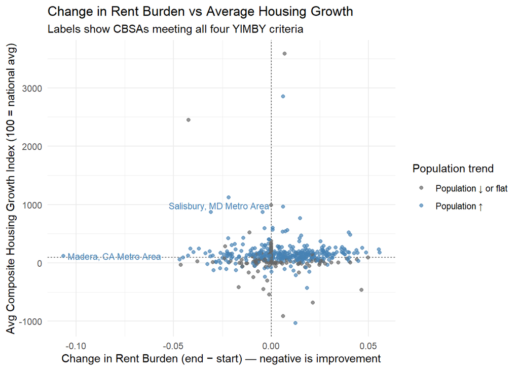

```r
ggplot(yimby_df, aes(x = change_rb, y = hg_composite_mean,
                     color = pop_growth_pct > 0)) +
  geom_hline(yintercept = 100, linetype = 2, linewidth = 0.3) +
  geom_vline(xintercept = 0,   linetype = 2, linewidth = 0.3) +
  geom_point(alpha = 0.7) +
  ggrepel::geom_text_repel(
    data = subset(yimby_df, yimby_flag),
    aes(label = NAME), size = 3, max.overlaps = 15, show.legend = FALSE
  ) +
  scale_color_manual(values = c("FALSE" = "grey40", "TRUE" = "steelblue"),
                     labels = c("Population ↓ or flat","Population ↑"),
                     guide = guide_legend(title = "Population trend")) +
  labs(
    title = "Change in Rent Burden vs Average Housing Growth",
    subtitle = "Labels show CBSAs meeting all four YIMBY criteria",
    x = "Change in Rent Burden (end − start) — negative is improvement",
    y = "Avg Composite Housing Growth Index (100 = national avg)"
  ) +
  theme_minimal(base_size = 11)
```

### 6.2 Rent Burden Over Time for Flagged CBSAs

[figure not shown]

```r
flag_ids <- yimby_df %>% filter(yimby_flag) %>% pull(GEOID)

rb_index %>%
  filter(GEOID %in% flag_ids) %>%
  ggplot(aes(x = year, y = rent_burden, group = NAME, color = NAME)) +
  geom_line(alpha = 0.8, linewidth = 0.8) +
  scale_y_continuous(labels = percent_format(accuracy = 1)) +
  guides(color = guide_legend(title = "Flagged CBSAs", ncol = 1)) +
  labs(
    title = "Rent Burden Over Time for Flagged (YIMBY-like) CBSAs",
    x = "Year", y = "Rent Burden"
  ) +
  theme_minimal(base_size = 11) +
  theme(legend.position = "bottom")
```

## 7 Policy Brief

**Policy Brief: Advancing YIMBY Housing Reform Through Federal Incentives**

**Overview**

**Identifying Sponsors**

**Local Impact and Support**

This legislation would help both types of cities.

- For growing, high-rent cities, the bill provides federal matching grantsto expand infrastructure and housing capacity, ensuring new development keeps pace with population growth.
- For more affordable but slower-growing metros, it offers incentives for smart infill development, helping maintain economic vitality while preventing future shortages.

**Supporting Interest Groups**

- Construction and Building Trade Workers:

This bill directly benefits construction-related jobs by boosting the number of permitted housing projects nationwide. An estimated 10–15% increase in annual building activity could create thousands of stable, skilled-labor positions. As local governments expand development, these workers will see more consistent employment and higher wages.

- Teachers and Healthcare Employees:

**Metrics for Evaluation**

Two primary metrics are recommended for tracking progress:

- Rent Burden Index – Measures the share of income spent on rent, standardized so that 100 equals the national average in the first year. A declining index signals improved affordability.
- Housing Growth Index– Combines instantaneous (permits per 1,000 residents) and rate-based (permits relative to population growth) measures. A higher score reflects stronger housing expansion relative to demand.

**Conclusion**

This bill would empower cities to accelerate housing construction, stabilize rents, and sustain economic growth. By linking federal funding to measurable outcomes in affordability and housing expansion, the program aligns local incentives with national goals for equitable, sustainable urban development.

## 8 Extra Credit Opportunity #01: Relationship Diagram

### 8.1 Relationship Diagram

The relationship diagram below shows how the main datasets in this project are connected. Each table—such as Income, Rent, Population, Households, and Permits—shares common keys (GEOID and year), which allow them to be joined for analysis. This structure makes it possible to study how population, income, and housing growth interact to influence affordability across different metropolitan areas.

[figure not shown]

## 9 Extra Credit #02: Highlighting Important Units in a Spaghetti Plot

### 9.1 It was completed in Task 3 (Average Household Size Over Time).